# Health status results

mauricio

2/27/2021

# 1. Scenarios

In this section, we test how grouping stocks by their initial stock affect the profits, biomass and effort allocation. We are considering 3 species/fish have a healthy stock (X_0 = 50), and 2 species/fish are overfished (X_0 = 15) at time zero.

We considered 3 arrangement for the quota baskets:  
- *Species with similar health status:* we have a QB of healthy stocks and a group of overfished stocks.  
- *The healthy species predominates in a basket:* we have a QB were the healthy species predominates (2 healthy stocks and 1 overexploited stock), and the other basket has the remaining species (1 healthy stock and 1 overexploited stock).  
- *The overfished species predominates in a basket:*we have a QB were the overfished species predominates (1 healthy stock and 2 overexploited stocks), and the other basket has the remaining species (2 healthy stocks).

We are going to compare these arrangements in terms of biomass, efforts, ant total profits.

## 1.1 Parameters

| Species | r | K | Starting stock (X) | price |
| --- | --- | --- | --- | --- |
| 1 | 0.2 | 100 | 50 | 20 |
| 2 | 0.2 | 100 | 50 | 20 |
| 3 | 0.2 | 100 | 50 | 20 |
| 4 | 0.2 | 100 | 15 | 20 |
| 5 | 0.2 | 100 | 15 | 20 |

| Tech | q1 | q2 | q3 | q4 | q5 | cost |
| --- | --- | --- | --- | --- | --- | --- |
| 1 | 0.04 | 0.01 | 0.01 | 0.01 | 0.01 | 1 |
| 2 | 0.01 | 0.04 | 0.01 | 0.01 | 0.01 | 1 |
| 3 | 0.01 | 0.01 | 0.04 | 0.01 | 0.01 | 1 |
| 4 | 0.01 | 0.01 | 0.01 | 0.04 | 0.01 | 1 |
| 5 | 0.01 | 0.01 | 0.01 | 0.01 | 0.04 | 1 |

# 2. Biomass

## 2.1 Biomass per species

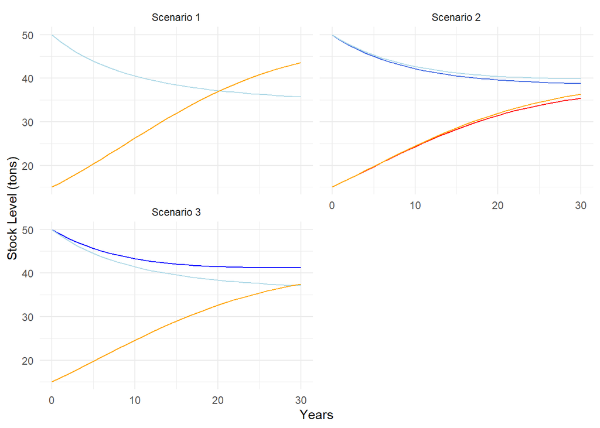

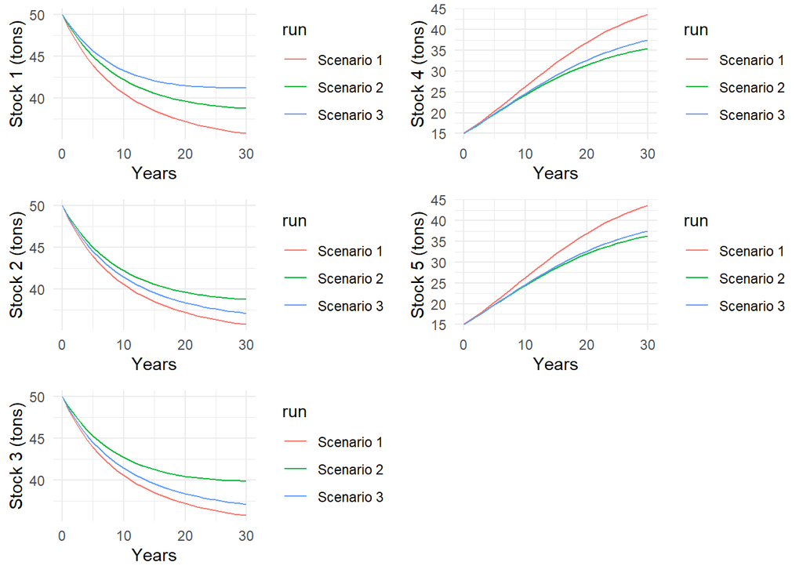

- Holding the rest of variables constant, the healthy stocks decline more in baskets dominated by healthy stocks.  
- Holding the rest of variables constant, the overfished stocks recover more in the baskets dominated by them.

## 2.2 Total biomass in the ocean

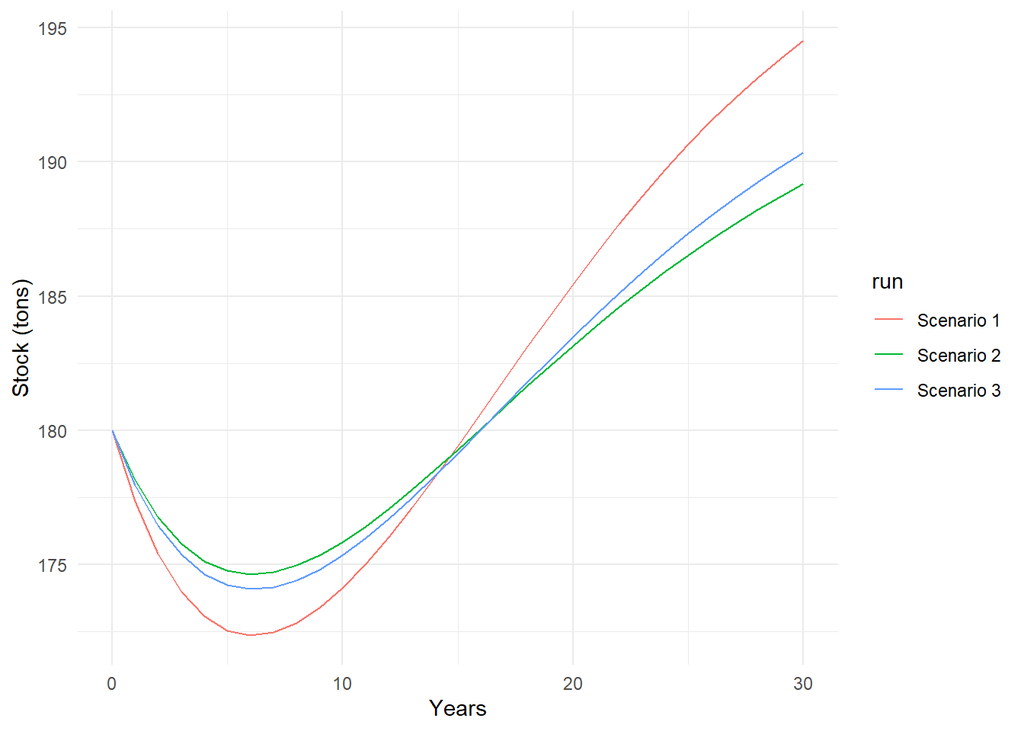

Holding the other of parameters similar among species, the total stock declines during the first 5 years and recovers in the long term. Scenario 1 provides better stock results on the long term, but the trade off is putting additional pressure on the healthy stocks.

# 3. Effort

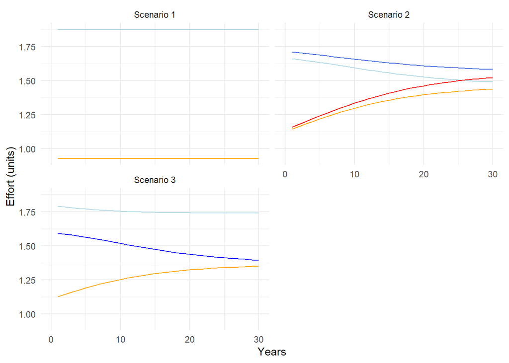

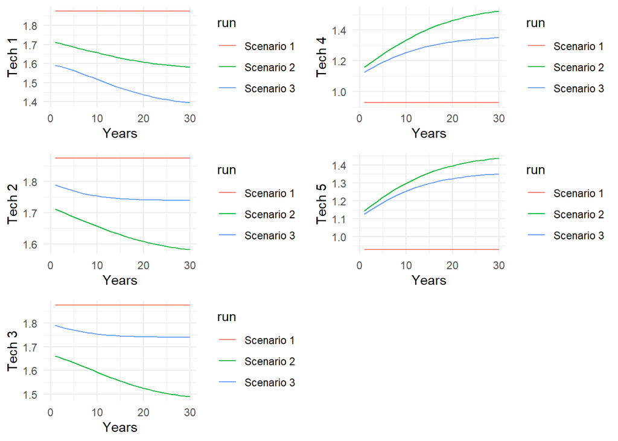

- Holding the other variables constant, we observe that baskets of similar elements display uniform effort units across all the period of analysis.  
- In the other scenarios, the effort favorable in harvesting overfished species increase while these species recover they stock.

# 4. Profit

# 4.1 Profit per technology

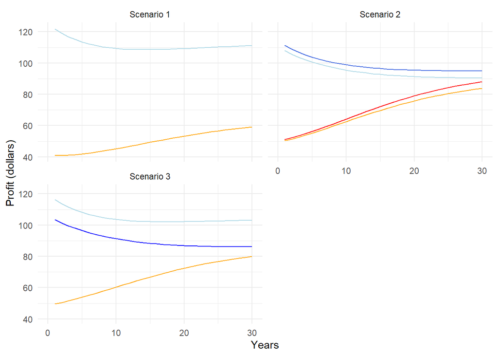

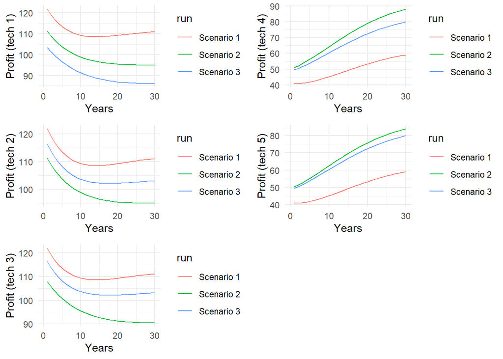

- Grouping healthy species (scenario 1) provide greater profits in their favorable technologies in all scenarios.  
- Grouping overfished species (scenario 1) provide less profits in their favorable technologies in all scenarios.  
- Grouping overfished species with healthy species, favor the increase of profits in tecnologies favorable for overfishe species.

# 4.2 Total profit per scenario

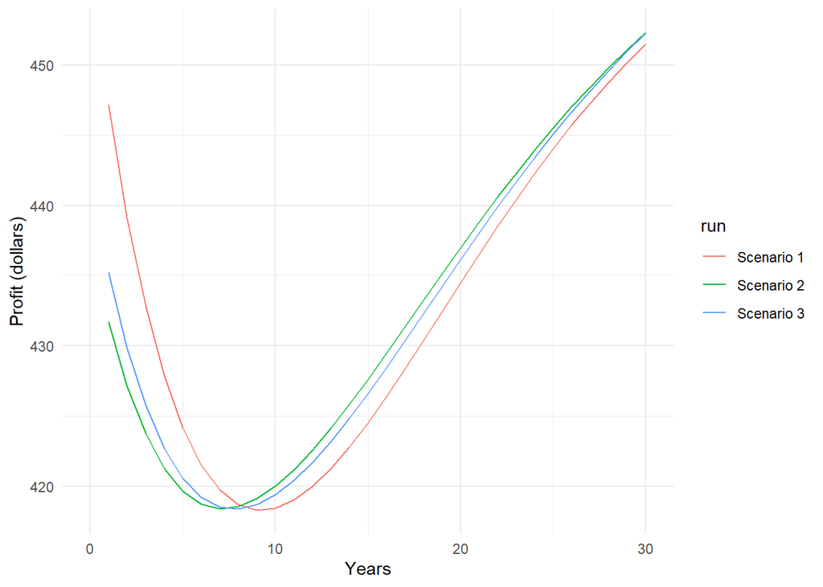

- Scenario 1 provides greater total profits in the short term.

# 5. Summary

**Stocks**  
- Holding the rest of variables constant, the healthy stocks decline more in baskets dominated by healthy stocks.  
- Holding the rest of variables constant, the overfished stocks recover more in the baskets dominated by them.

**Effort**  
- Holding the other variables constant, we observe that baskets of similar elements display uniform effort units across all the period of analysis.  
- In the other scenarios, the effort favorable in harvesting overfished species increase while these species recover they stock.

**Profit**  
- Grouping healthy species (scenario 1) provide greater profits in their favorable technologies in all scenarios.  
- Grouping overfished species (scenario 1) provide less profits in their favorable technologies in all scenarios.  
- Grouping overfished species with healthy species, favor the increase of profits in tecnologies favorable for overfishe species.  
- Scenario 1 provides greater total profits in the short term.